# Exploratory Analysis

## Project title

Life Expectancy Worldwide

### Authors

- Shivani Ramesh (rameshsh@uw.edu)
- Wilson Boudreaux (wlsnfb@uw.edu)
- Xingzhu Liu (xliu38@uw.edu)
- Kendrick Echevarria (echevken@uw.edu)

### Date

**Summer 2023**

### Abstract

We will be investigating the life expectency between several different countries. We are concerned with this because it affects the global health of the world population. We plan to use this data to investigate what influences life expectancies worldwide.

### Keywords

Life expectancy, immunizations, GDP, economic/demographic information.

### Introduction

- How does alcohol consumption influence life expectancy in different regions?
- Can BMI impact life expectancy?
- Is there a correlation between life expectancy and the prevalence of diseases ?
- How does region correlate with infant/child deaths?  
  These questions were developed due raising concerns about health disparities, need for evidence-based solutions, and preventive healthcare. We want to see how lifestyle choices, diseases, and life expectancy are connected to give policymakers, healthcare folks, and researchers useful insights for improving public health and longevity. Finding the factors that affect life expectancy will help us create better strategies and plans to make a real impact on people’s health.

### Related Work

Our project investigates life expectancy and its correlation with lifestyle variables and diseases, such as infant/child mortality, alcohol consumption, BMI, hepatitis, and measles. Life expectancy is a crucial public health indicator reflecting population well-being. Understanding these relationships can guide targeted interventions to enhance health and longevity. Numerous studies have explored these topics. For example, Rajaratnam et al. (2010) analyzed global child mortality patterns and risk factors, offering insights into reducing infant and child deaths through early interventions. Rehm et al. (2017) examined alcohol consumption’s impact on life expectancy, highlighting the need for alcohol-related harm prevention. Di Angelantonio et al. (2016) studied BMI’s associations with mortality risks, stressing the importance of obesity prevention and management efforts. Our analysis aims to understand how lifestyle variables and diseases influence life expectancy, offering valuable insights for public health policies and interventions. Identifying modifiable risk factors can improve population health and longevity. Our findings assist policymakers, healthcare practitioners, and researchers in designing evidence-based strategies for better overall well-being.  
Rajaratnam, J. K., Marcus, J. R., Levin-Rector, A., Chalupka, A. N., Wang, H., Dwyer, L., … & Murray, C. J. (2010). Worldwide mortality in men and women aged 15-59 years from 1970 to 2010: a systematic analysis. The Lancet, 375(9727), 1704-1720.  
Rehm, J., Hasan, O. S., Black, S. E., Shield, K. D., Roerecke, M., & Lachenmeier, D. W. (2017). Alcohol use and cause-specific mortality in Russia: a retrospective case–control study of 48 557 adult deaths. The Lancet, 390(10104), 946-958.  
Di Angelantonio, E., Bhupathiraju, S. N., Wormser, D., Gao, P., Kaptoge, S., Berrington de Gonzalez, A., … & Nordestgaard, B. G. (2016). Body-mass index and all-cause mortality: individual-participant-data meta-analysis of 239 prospective studies in four continents. The Lancet, 388(10046), 776-786.

### The Dataset

> Where did you find the data? Please include a link to the data source

Our group finds the data from the Kaggle website through the following link https://www.kaggle.com/datasets/lashagoch/life-expectancy-who-updated.

> Who collected the data?

The data was initially collected by World Health Organization (WHO) with the help of Deeksha Russell and Duan Wang and finally revised by Lasha Gochiashivili.

> How was the data collected or generated?

The data was collected from the Global Health Observatory(GHO) data repository, which focuses on the health status under the impact of many other factors across all countries.

> Why was the data collected?

The main purpose of the data collection was to understand how life expectancy was affected by immunization, mortality, economic; and social factors from 2000 to 2015 across 197 countries. As the observations varied in different countries, it gave a more intuitive way for the country to determine the predicting factor that was mainly caused by the lower value of life expectancy. Therefore, there would be enough space and explicit direction for the country to make the improvement to prolong the life expectancy of the overall population.

> How many observations (rows) are in your data?

```r
n_observation <- nrow(life_expectancy_data_url)
n_observation
```

[output not shown]

There are 2864 observations in the data.

> How many features (columns) are in the data?

```r
n_features <- ncol(life_expectancy_data_url)
n_features
```

[output not shown]

There are 21 features in the data.

> What, if any, ethical questions or questions of power do you need to consider when working with this data?

There are no apparent ethical dilemmas about working with this data, but it is possible that the results could pose ethical dilemmas about quality of life across different countries. And, we would ensure the transparency, fairness, and accountability during the data analysis.

> What are possible limitations or problems with this data? (at least 200 words)

One potential problem is that data quality and consistency may vary across different countries and regions. Discrepancies in data collection methods, reporting standards, and healthcare infrastructure can lead to inaccuracies and hinder comparative analysis. Another problem is the missing data and gaps in the time series. Some countries might not have consistently reported life expectancy data over the years, making it difficult to obtain a comprehensive and continuous dataset. Inputting missing values may introduce biases and uncertainties into the analysis. Moreover, disparities in healthcare infrastructure and access to healthcare services can affect the accuracy and completeness of life expectancy data. Regions with better healthcare systems might have more accurate and up-to-date information, while regions with weaker systems may face challenges in data collection and reporting. This disparity can introduce biases, favoring regions with more developed healthcare systems in comparative analyses.

Assuming you answer your research questions, briefly describe the expected or possible implications for technologists, designers, and policymakers. (at least 150 words)

Since we are looking at the life expectancy rates across many different countries, we should be able to address many similarities and defining factors that increase or decrease the life expectancy in each country. Since there are many different years for each country with information on each statistic, we are also able to look for a trend in life expectancy and compare it to other trends of other statistics in each country and overall. If we are able to answer our research questions by analyzing the data in the sets, we will be able to identify certain factors that go into increasing and decreasing life expectancy, and target the main contributing factors in each country. Policymakers from every country will be able to target what needs to be changed within that specific country in order to ensure the highest life expectancy. This is mainly something that affects policymakers within each country because they are the ones who are able to allocate funds and support to certain sanctions with their country.

### Limitations & Challenges

What challenges or limitations might you need to address with your project idea more broadly? Briefly discuss. (at least 150 words)

The project’s broader challenges involve potential data issues like missing values and outliers, which might impact analysis accuracy. The dataset’s scope and coverage limitations, focusing on specific regions and omitting confounding variables like socioeconomic status, could affect generalizability. Establishing causation between alcohol consumption and life expectancy requires more rigorous study designs, and cultural variations may introduce biases. To address these challenges, thorough data cleaning, robust statistical methods, and diverse datasets are essential. Caution must be exercised in making causal claims without supporting evidence, acknowledging uncertainties in findings.

### Table

```
## # A tibble: 9 × 5
##   Region               Mean_Life_Expectancy Median_Income Mean_Alcohol_Consump…¹
##   <chr>                               <dbl>         <dbl>                  <dbl>
## 1 North America                        77.8        40762.                   7.05
## 2 European Union                       77.7        22152                   10.8
## 3 Rest of Europe                       74.5         4433                    7.58
## 4 Middle East                          74.0        13550.                   0.88
## 5 South America                        72.8         6076.                   5.75
## 6 Central America and…                 72.4         6131                    5.62
## 7 Oceania                              69.5         2998.                   2.88
## 8 Asia                                 69.4         2116                    2.4
## 9 Africa                               57.8         1101                    2.98
## # ℹ abbreviated name: ¹Mean_Alcohol_Consumption
## # ℹ 1 more variable: Mean_Adult_Mortality <dbl>
```

### Chart 1

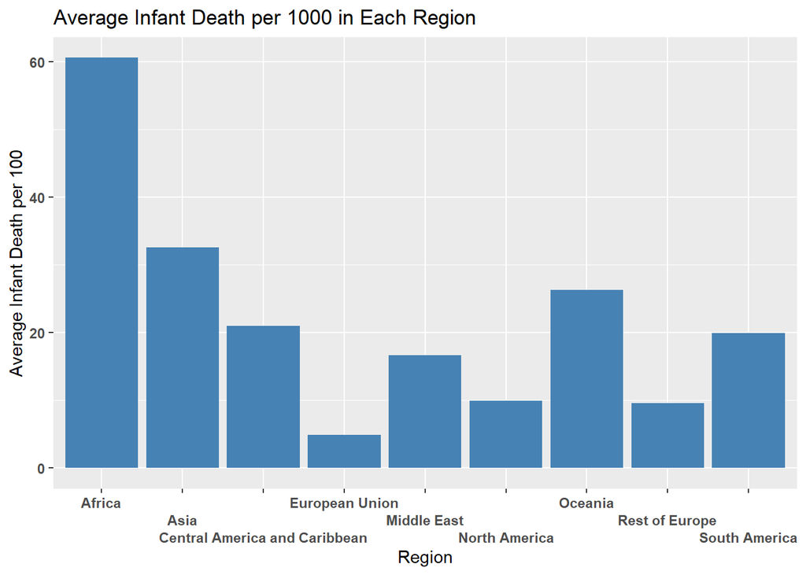

I used a bar plot in order to compare each region’s infant mortality rate. The reason I used a bar plot is that a bar plot is able to display each region distinctly and it’s visually easy to compare the rates between them because of the size of the bars. This information reveals that the highest infant mortality rate is in the region of Africa at 60 deaths per 1000. This information spans from 2000 to 2015. The lowest rate is in the European Union at roughly 5 deaths per 1000.

### Chart 2

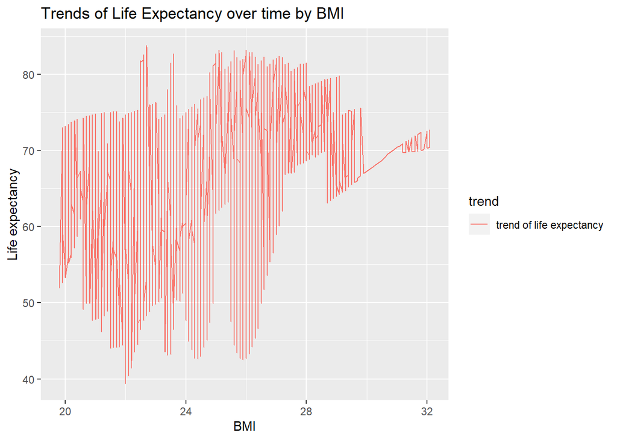

The line chart reveals the relationship between BMI and life expectancy. BMI value recorded within these fifteen years has set up the range between 19.8 to 32.1. It clearly shows that BMI around 22 to 26 has a wider range of life and a slightly higher life span than the extreme BMI number at the very beginning and end of the chart. This indicates that the BMI value can be considered to be a decisive factor on human physical condition. To extend the life expectancy, maintaining in the healthiest range of BMI plays a vital role on the public health system.

### Chart 3

[figure not shown]